# AUTOMATIZAÇÃO DE TRADING COM R

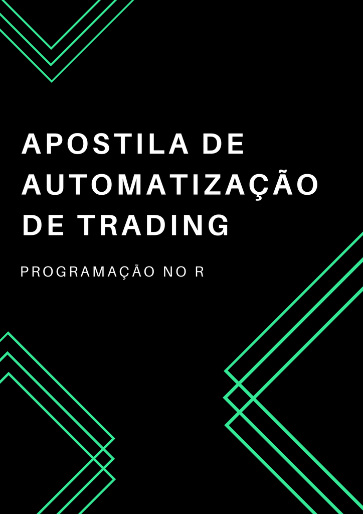

# SOBRE A APOSTILA

Organizadores:

- **Victor Valerio**;
- **Juliano Silva**.

# PRIMEIRA REGRA DE NEGOCIAÇÃO

Como primeiro passo utilizaremos o “filtro simples” como primeira regra de negociação, uma abordagem extremamente trivial e, portanto, pouco usual. A expectativa com esta aplicação é que se compreenda a lógica de formalização de uma regra de negociação a partir de um exemplo acessível, sem qualquer compromisso com o desempenho.

$$Comprar: \frac{P_t}{P_{t-1}} > 1+\beta$$
Em que $P_t$ corresponde ao preço de fechamento no período $t$, $P_{t-1}$ corresponde ao preço de fechamento no período $t-1$, isto é, imediatamente anterior e $\beta$ corresponde ao sinal, ou seja, um escalar positivo $\beta>0$ e arbitrariamente definiremos na regra de negociação.

Vamos iniciar a regra de negociação a partir das etapas do ciclo da ciência de dados. Assim, em primeiro lugar implementaremos a fase de importação dos dados que, neste exemplo, consistirá no uso do IBOVESPA com o ticker *^BVSP*.

```r
# Parâmetros para importação dos dados:

inicio <- Sys.Date()-120
fim <- Sys.Date()
ticker <- '^BVSP'


# Importação dos dados com quantmod (yahoo finanças):

ibovespa <- quantmod::getSymbols(Symbols = ticker,
                                 from = inicio,
                                 to = fim,
                                 auto.assign = FALSE)


# Impressão no console das primeiras 5 linhas:

head(ibovespa, n = 5)
```

[output not shown]

```r
# Seleção do preço de fechamento apenas:

preco_fechamento <- quantmod::Cl(ibovespa)


# Cômputo das variações diárias dos preços de fechamento:

variacao_preco <- preco_fechamento/lag(preco_fechamento) - 1


# Definição do parâmetro de compra:

beta <- 0.005


# Resultados dos sinais a partir das variações e do parâmetro de compra:

sinal <- c(0)

for (i in 2:length(preco_fechamento)){

  if (variacao_preco[i] > beta){

    sinal[i] <- 1

  } else

    sinal[i] <- 0
}


# Adequando as datas dos sinais:

sinal <- xts::reclass(sinal, preco_fechamento)


# Impressão no console das primeiras 5 linhas:

head(sinal, n = 5)
```

```
           [,1]
2021-07-14    0
2021-07-15    0
2021-07-16    0
2021-07-19    0
2021-07-20    1
```

Gerando análise gráfica a partir dos dados importados, com algumas alterações mínimas de layout e adicionando os sinais calculados com base na regra traçada.

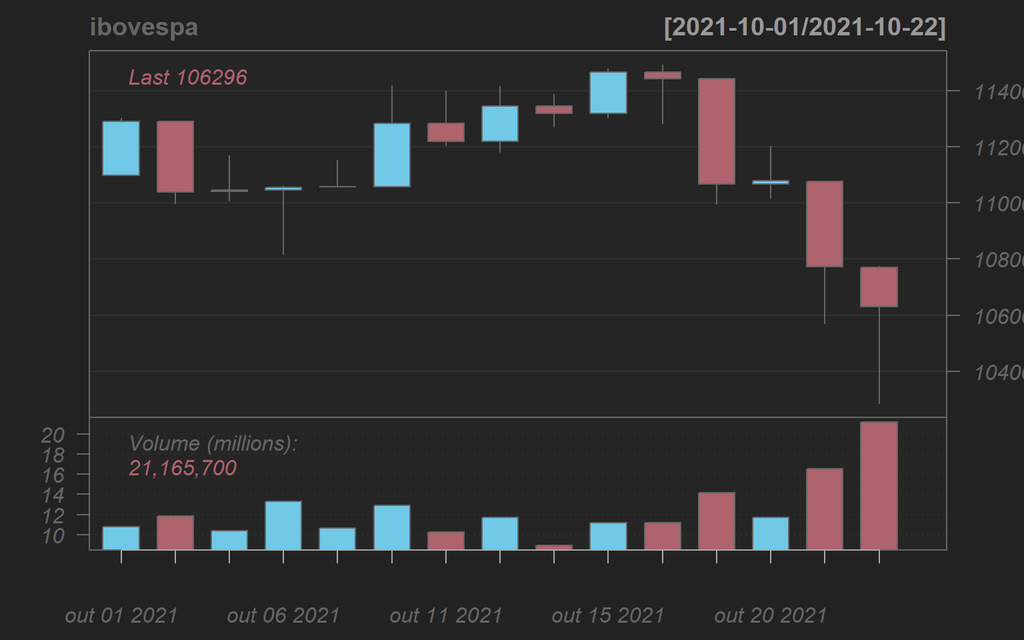

```r
# Gerando o gráfico apenas para o mês de outubro:

quantmod::chartSeries(ibovespa,
                      subset= '2021-10-01::2021-10-24',
                      theme = quantmod::chartTheme('black',
                                                   up.col='#70c9e7',
                                                   dn.col='#af636c'))
```

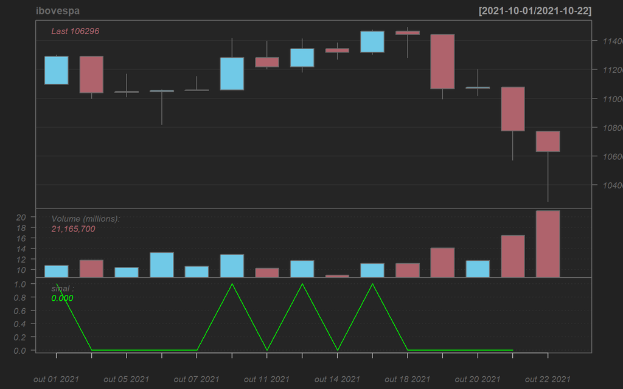

```r
# Adicionando os sinais de compra:

quantmod::addTA(sinal, col = 'green')
```

A ordem é pautada no resultado do dia imediatamente anterior. Conforme apresentado a seguir:

```r
# Deve-se comprar com base no sinal anterior:

ordem <- lag(sinal,1)


# Alterando o nome da coluna:

names(ordem) <- 'filtro'


# Impressão no console das primeiras 5 linhas:

head(ordem, n = 5)
```

```
           filtro
2021-07-14     NA
2021-07-15      0
2021-07-16      0
2021-07-19      0
2021-07-20      0
```

Para manter simples, a avaliação da negociação deverá ser assim definida:

- **Abertura**: compra;
- **Fechamento**: vende;
- **Tamanho da Negociação**: total.

Neste caso, o retorno diário pode ser exposto como:

```r
# Cálculo do retorno diário obtido nos dias em que a ordem deveria ser
# executada de acordo com a estratégia traçada:

retorno_diario <- quantmod::dailyReturn(ibovespa) * ordem


# Impressão no console das primeiras 5 linhas:

head(retorno_diario, n = 5)
```

```
           daily.returns
2021-07-14            NA
2021-07-15             0
2021-07-16             0
2021-07-19             0
2021-07-20             0
```

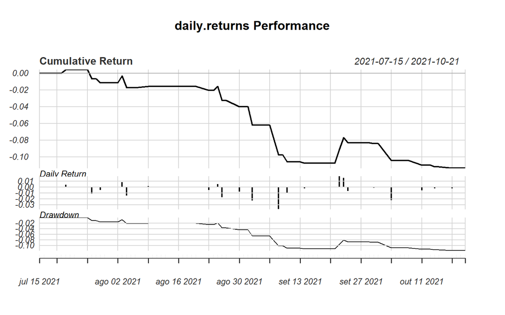

```r
# Avaliando o resutaldo no périodo traçado (retorno acumulado):

PerformanceAnalytics::charts.PerformanceSummary(retorno_diario)
```